# Predicting Scrabble Rating Based on Gameplay

### Introduction

Scrabble is a popular word game played in nearly 121 countries around the world. The primary focus of the game is to create various words with a given set of letters. Players are initially given a certain number of tiles containing letters, and they take turns placing down the letters on the board and creating words. After each turn, players are given points based on the letters which can be multiplied by various point modifiers scattered throughout the board. Players also draw new tiles after each turn to ensure that they have 7 tiles on their rack (the item which holds their tiles). Once all letters have been drawn and a player places their last tile, the game ends. The game can also end if no more plays are possible. More in-depth rules can be found [here](https://scrabble.hasbro.com/en-us/rules).

Scrabble was originally a board game; however, its growing popularity and success, brought forth a growing community interested in playing Scrabble online. Woogles.io is a site forged from this very idea. It is a non-profit run by a team of volunteers which are looking to create an online resource of word games, one of which is Scrabble (or OMGwords as it is called on their site).

The project hopes to analyze Scrabble gameplay from Woogles.io and construct a model to predict a player's rating based on the data given. Knowing why certain players have a higher rating can help others improve their own gameplay. Higher rated players do certain things betterthan lower rated players, and by analyzing the differences, lower rated players can study and learn how to become better at the game as well.

### Data Processing

Let's start by first obtaining and cleaning up our data. Our data is obtained from this [Kaggle competition](https://www.kaggle.com/competitions/scrabble-player-rating/data). The data analyzes matches between Scrabble bots, of which there are 3 difficulties, and their human opponents. The goal of the competition is to predict the rating of the human opponent based on the given data.

First, let's import pandas for data exploration and let's also import matplotlib and seaborn for displaying graphs.

```python
import pandas as pd
import seaborn as sns
import matplotlib.pyplot as plt
import numpy as np
import warnings
warnings.filterwarnings("ignore")
```

Let's start by exploring the game data.

```python
games_data = pd.read_csv("games.csv")
games_data
```

|  | game_id | first | time_control_name | game_end_reason | winner | created_at | lexicon | initial_time_seconds | increment_seconds | rating_mode | max_overtime_minutes | game_duration_seconds |
| --- | --- | --- | --- | --- | --- | --- | --- | --- | --- | --- | --- | --- |
| 0 | 1 | BetterBot | regular | STANDARD | 1 | 2022-08-26 03:38:49 | NWL20 | 1200 | 0 | CASUAL | 1 | 674.844274 |
| 1 | 2 | Super | regular | STANDARD | 1 | 2022-08-10 19:19:59 | CSW21 | 3600 | 0 | RATED | 1 | 364.214418 |
| 2 | 3 | BetterBot | regular | STANDARD | 1 | 2022-09-04 08:04:27 | CSW21 | 900 | 0 | RATED | 5 | 492.268262 |
| 3 | 4 | BetterBot | regular | RESIGNED | 0 | 2022-09-12 02:36:19 | CSW21 | 3600 | 0 | CASUAL | 1 | 350.861141 |
| 4 | 5 | STEEBot | regular | STANDARD | 0 | 2022-09-06 04:31:36 | NWL20 | 1200 | 0 | CASUAL | 1 | 642.688722 |
| ... | ... | ... | ... | ... | ... | ... | ... | ... | ... | ... | ... | ... |
| 72768 | 72769 | browndav | blitz | STANDARD | 0 | 2022-09-07 13:24:13 | CSW21 | 180 | 0 | RATED | 1 | 218.043751 |
| 72769 | 72770 | HastyBot | regular | TIME | 0 | 2022-09-04 00:13:24 | CSW21 | 3600 | 0 | RATED | 1 | 3662.659287 |
| 72770 | 72771 | HastyBot | regular | STANDARD | 0 | 2022-09-19 03:28:44 | ECWL | 900 | 0 | CASUAL | 10 | 236.133634 |
| 72771 | 72772 | Gtowngrad | regular | STANDARD | 0 | 2022-08-31 15:57:38 | NWL20 | 900 | 0 | RATED | 1 | 681.370077 |
| 72772 | 72773 | HastyBot | regular | STANDARD | 1 | 2022-08-27 09:13:08 | CSW21 | 1200 | 0 | RATED | 1 | 719.720262 |

72773 rows × 12 columns

In the games dataset, there are 12 columns:

- game_id
- first (the name of the player that went first)
- time_control_name (either regular, rapid, blitz, or ultrablitz)
- game_end_reason (standard, resigned, time, or consecutive zeroes)
- winner (0 indicates that the first player won, 1 indicates that the second player won, and -1 indicates that the game resulted in a tie)
- created_at
- lexicon (the lexicon of the English alphabet that was used for the game)
- initial_time_seconds (the number of seconds the player start off with)
- increment_seconds (time increment each player gets each time they play a turn)
- rating_mode (Whether the game counts towards players' ratings. It is either casual or rated)
- max_overtime_minutes (an integer between 0 and 10 which represents the maximum number of overtime a player can get)
- game_duration_seconds

Most of the stuff listed above is self-explanatory but here are some additional details that may be useful:

- First is either the name of the bot or the nickname of the player based on who went first. There are 3 difficulties of bots: BetterBot (beginner), STEEBot (intermediate), and HastyBot (advanced).
- If no one scores any points for 6 consecutive turns, the game will end. This is listed as consecutive zeroes in the game_end_reason column.
- For this data, lexicon is either ECWL, [NWL20/NSWL20](https://scrabbleplayers.org/w/NASPA_School_Word_List#:~:text=The%20NASPA%20School%20Word%20List,considered%20appropriate%20for%20school%20use.), or [CSW21](https://scrabbleplayers.org/w/Collins_tournaments_and_ratings). In general, there are 2 main authorities for Scrabble word lists: NASPA and Collins. Collins makes the word lists for most countries while NASPA makes the world lists for the US. NASPA lists tend to start with an N such as "NWL" or "NSWL" while Collins lists tend to start with "CSW". The numbers at the end indicate when the list was published.
- Each overtime minute, or fractional minute, used by the player will result in a loss of 10 points

#### Turns Data

The turns data contains data about each turn in the game. Since there are a lot of special cases, this section will involve a lot of background. Let's start by creating a dataframe out of the turns data.

```python
turns_data = pd.read_csv("turns.csv")
turns_data
```

|  | game_id | turn_number | nickname | rack | location | move | points | score | turn_type |
| --- | --- | --- | --- | --- | --- | --- | --- | --- | --- |
| 0 | 1 | 1 | BetterBot | DDEGITT | 8G | DIG | 10 | 10 | Play |
| 1 | 1 | 2 | stevy | AEHOPUX | 7H | HAP | 18 | 18 | Play |
| 2 | 1 | 3 | BetterBot | DEELTTU | 6I | LUTE | 16 | 26 | Play |
| 3 | 1 | 4 | stevy | EMORSUX | 5K | UM | 16 | 34 | Play |
| 4 | 1 | 5 | BetterBot | ACDEITU | L5 | ..DICATE | 28 | 54 | Play |
| ... | ... | ... | ... | ... | ... | ... | ... | ... | ... |
| 2005493 | 72773 | 22 | adola | ABINRRU | 15N | IN | 18 | 376 | Play |
| 2005494 | 72773 | 23 | HastyBot | EGHIIP | H12 | .HIG | 24 | 331 | Play |
| 2005495 | 72773 | 24 | adola | ABRRU | 15E | BRA. | 7 | 383 | Play |
| 2005496 | 72773 | 25 | HastyBot | EIP | 7A | PIE | 11 | 342 | Play |
| 2005497 | 72773 | 26 | HastyBot | NaN | NaN | (RU) | 4 | 346 | End |

2005498 rows × 9 columns

In the turns dataset, there are 9 columns:

- game_id
- turn_number
- nickname (the name of the player taking the turn)
- rack (the current tiles in the player's rack. A ? represents a wildcard tile which can be substituted for letter)
- location (the place at which a move is played)
- move (the tiles that are placed down in a turn)
- points (the points that a player gained during that turn)
- score (the player's total score after that turn)
- turn_type (the type of that turn)

Most of the stuff listed above is self-explanatory but some of it does need additional explanation. There also are a lot of special scenarios which can change the values in certain columns. I have tried to highlight most of them below.

- Nickname is either the name of the bot or the nickname of the player based on who went first. There are 3 difficulties of bots as mentioned earlier.
- A turn in Scrabble can build a word off of existing letters on the board and a "." in the move section is used to indicate that an letter already on the board was used for that turn. A ? in the move column means that a wildcard was exchanged while a lowercase letter in the move column indicates that a wildcard was substituted for that letter

Before moving on, it is important to note the various nuances based on the turn type. Different turn types may result in special characters in certain columns. Here is a description of all of the turn types:

- Play is the standard turn type where players just play a move.
- An exchange is where the player exchange some of the tiles on their rack with tiles in the bag (the item which holds all of the undistributed tiles). The move for that turn is marked with a "-" in front such as -ABC to indicate that the player exchanged their A, B, and C tiles. The rack column displays the player's tiles before the exchange. Additionally, an exchange awards no points and the location column shows null for an exchange.
- A pass indicates that a player simply passed on their turn and played no move. The move column is "-" for this type of move and the location is null.
- A timeout indicates that a player has ran out of time. The location for that turn is null and the move is (time). The points are negative because 10 points are deducted from a player's score for each minute, or fractional minute, that a player plays exceeding the game's initial time limit.
- The "End" turn type indicates that a game as ended. In the given data, the only way that a game ends is if one person is completely out of letters to play. The player with no tiles is given the "End" turn and the rack and location of that turn are null. Additionally, the opponent's remaining tiles are scored based on the value of each letter and the player with no tiles is awarded the sum of their opponent's tiles. The move for an end turn is the opponent's rack surrounded by parentheses. For example, if the opponent has A and O left, the move for the "End" turn would be (AO).

A "Challenge" turn type has even more nuances. A challenge occurs when one player questions the validity of another player's word. The word is searched in the appropriate lexicon (as indicated in the games data) and if it exists, the challenge is deemed unsuccessful.

To fully understand these, let's look at some examples

```python
turns_data.iloc[6812:6820]
```

|  | game_id | turn_number | nickname | rack | location | move | points | score | turn_type |
| --- | --- | --- | --- | --- | --- | --- | --- | --- | --- |
| 6812 | 251 | 28 | hulkbuster | EGLNOST | 14B | TOE | 20 | 205 | Play |
| 6813 | 251 | 29 | STEEBot | ADENOPT | B2 | PA.ED | 33 | 573 | Play |
| 6814 | 251 | 30 | hulkbuster | EGLNORS | 13A | GER | 23 | 228 | Play |
| 6815 | 251 | 31 | STEEBot | NOT | 14M | NOT | 16 | 589 | Play |
| 6816 | 251 | 32 | STEEBot | NaN | NaN | (challenge) | 0 | 589 | Challenge |
| 6817 | 251 | 33 | STEEBot | NaN | NaN | (LNOS) | 8 | 597 | End |
| 6818 | 252 | 1 | meetsumeet | DEEILQR | 8G | QI | 22 | 22 | Play |
| 6819 | 252 | 2 | STEEBot | EHILTUU | 9E | HUI | 19 | 19 | Play |

Above, we can see an example of an unsuccessful challenge. In row 6815 of turns_data, bot "STEEBot" put down the word "NOT". In the next turn, user "hulkbuster" challenged that validity of the word and lost. As we can see, unsuccessful challenges result no rack, no location, no points awarded, and no change in a player's score. Additionally, the move is written as (challenge).

Fun fact: Some formats penalize the challenger if the challenge is unsuccessful.

Now let's look at an example of a successful challenge.

```python
turns_data.iloc[530:540]
```

|  | game_id | turn_number | nickname | rack | location | move | points | score | turn_type |
| --- | --- | --- | --- | --- | --- | --- | --- | --- | --- |
| 530 | 19 | 30 | HivinD | NaN | NaN | (II) | 4 | 380 | End |
| 531 | 20 | 1 | STEEBot | AAEINSU | 8H | AUA | 6 | 6 | Play |
| 532 | 20 | 2 | Favournew | AABDNRT | 9G | BAND | 19 | 19 | Play |
| 533 | 20 | 3 | STEEBot | EEEINOS | 10F | EE | 8 | 14 | Play |
| 534 | 20 | 4 | Favournew | AKRRTXY | 11D | TAXY | 45 | 64 | Play |
| 535 | 20 | 5 | Favournew | AKRRTXY | NaN | -- | -45 | 19 | Exchange |
| 536 | 20 | 6 | STEEBot | EGINOSS | 10I | SO | 13 | 27 | Play |
| 537 | 20 | 7 | Favournew | AKRRTXY | 11E | KAY | 30 | 49 | Play |
| 538 | 20 | 8 | STEEBot | EEGIINS | H11 | SIEGE | 32 | 59 | Play |
| 539 | 20 | 9 | Favournew | EIORRTX | 12C | EXIT | 31 | 80 | Play |

The final turn type is a Six-Zero Rule. This means that the last 6 turns all had a point score of 0. Let's see how this actually looks.

```python
turns_data.iloc[9878:9888]
```

|  | game_id | turn_number | nickname | rack | location | move | points | score | turn_type |
| --- | --- | --- | --- | --- | --- | --- | --- | --- | --- |
| 9878 | 364 | 31 | BB-8 | IU | 9C | I. | 6 | 312 | Play |
| 9879 | 364 | 32 | HastyBot | U | NaN | - | 0 | 361 | Pass |
| 9880 | 364 | 33 | BB-8 | U | NaN | - | 0 | 312 | Pass |
| 9881 | 364 | 34 | HastyBot | U | NaN | - | 0 | 361 | Pass |
| 9882 | 364 | 35 | BB-8 | U | NaN | - | 0 | 312 | Pass |
| 9883 | 364 | 36 | HastyBot | U | NaN | - | 0 | 361 | Pass |
| 9884 | 364 | 37 | BB-8 | U | NaN | - | 0 | 312 | Pass |
| 9885 | 364 | 38 | BB-8 | U | NaN | (U) | -1 | 311 | Six-Zero Rule |
| 9886 | 364 | 39 | HastyBot | U | NaN | (U) | -1 | 360 | Six-Zero Rule |
| 9887 | 365 | 1 | MarieDee | DDEIIRU | 8D | DRUID | 18 | 18 | Play |

As we can see, the only way to end the game if no more moves can be played is via the six-zero rule. Afer 6 consecutive zeroes, the next two turns are used to sum up the remaining tiles on each player's board and subtract the value of those tiles from the player's score.

Let's finish up our data processing by loading in the train and test csv's.

```python
train_data = pd.read_csv("train.csv")
train_data
```

|  | game_id | nickname | score | rating |
| --- | --- | --- | --- | --- |
| 0 | 1 | BetterBot | 335 | 1637 |
| 1 | 1 | stevy | 429 | 1500 |
| 2 | 3 | davidavid | 440 | 1811 |
| 3 | 3 | BetterBot | 318 | 2071 |
| 4 | 4 | Inandoutworker | 119 | 1473 |
| ... | ... | ... | ... | ... |
| 100815 | 72771 | HastyBot | 393 | 1614 |
| 100816 | 72772 | BetterBot | 442 | 1674 |
| 100817 | 72772 | Gtowngrad | 388 | 1364 |
| 100818 | 72773 | adola | 383 | 2075 |
| 100819 | 72773 | HastyBot | 346 | 2302 |

100820 rows × 4 columns

```python
test_data = pd.read_csv("test.csv")
test_data
```

|  | game_id | nickname | score | rating |
| --- | --- | --- | --- | --- |
| 0 | 2 | Super | 488 | NaN |
| 1 | 2 | BetterBot | 401 | 2000.0 |
| 2 | 7 | STEEBot | 377 | 2082.0 |
| 3 | 7 | Priya1 | 379 | NaN |
| 4 | 11 | STEEBot | 334 | 1829.0 |
| ... | ... | ... | ... | ... |
| 44721 | 72762 | kyjo55555 | 367 | NaN |
| 44722 | 72768 | HastyBot | 524 | 2356.0 |
| 44723 | 72768 | Maximilian | 357 | NaN |
| 44724 | 72769 | STEEBot | 626 | 2110.0 |
| 44725 | 72769 | browndav | 384 | NaN |

44726 rows × 4 columns

Both of these are pretty similar expect for the fact that the test data does not include the rating for the human player.

In order to make accessing the rating easier, let's specify the human and bot rating for each row in the train data.

```python
def evaluate(row, type):
  # If human rating is needed, you return the rating the player is a human
  if type == "human":
    if row.nickname not in ["BetterBot", "HastyBot", "STEEBot"]:
      return row.rating
  else:
    if row.nickname in ["BetterBot", "HastyBot", "STEEBot"]:
      return row.rating
  return None;

train_data["bot_rating"] = train_data.apply(lambda row: evaluate(row, "bot"), axis = 1)
train_data["human_rating"] = train_data.apply(lambda row: evaluate(row, "human"), axis = 1)
train_data
```

|  | game_id | nickname | score | rating | bot_rating | human_rating |
| --- | --- | --- | --- | --- | --- | --- |
| 0 | 1 | BetterBot | 335 | 1637 | 1637.0 | NaN |
| 1 | 1 | stevy | 429 | 1500 | NaN | 1500.0 |
| 2 | 3 | davidavid | 440 | 1811 | NaN | 1811.0 |
| 3 | 3 | BetterBot | 318 | 2071 | 2071.0 | NaN |
| 4 | 4 | Inandoutworker | 119 | 1473 | NaN | 1473.0 |
| ... | ... | ... | ... | ... | ... | ... |
| 100815 | 72771 | HastyBot | 393 | 1614 | 1614.0 | NaN |
| 100816 | 72772 | BetterBot | 442 | 1674 | 1674.0 | NaN |
| 100817 | 72772 | Gtowngrad | 388 | 1364 | NaN | 1364.0 |
| 100818 | 72773 | adola | 383 | 2075 | NaN | 2075.0 |
| 100819 | 72773 | HastyBot | 346 | 2302 | 2302.0 | NaN |

100820 rows × 6 columns

Let's also omit the test data since it does not provide any information about human rating.

```python
valid_game_ids = train_data["game_id"];
filtered_turns_data = turns_data[turns_data["game_id"].isin(valid_game_ids)]
filtered_turns_data
```

|  | game_id | turn_number | nickname | rack | location | move | points | score | turn_type |
| --- | --- | --- | --- | --- | --- | --- | --- | --- | --- |
| 0 | 1 | 1 | BetterBot | DDEGITT | 8G | DIG | 10 | 10 | Play |
| 1 | 1 | 2 | stevy | AEHOPUX | 7H | HAP | 18 | 18 | Play |
| 2 | 1 | 3 | BetterBot | DEELTTU | 6I | LUTE | 16 | 26 | Play |
| 3 | 1 | 4 | stevy | EMORSUX | 5K | UM | 16 | 34 | Play |
| 4 | 1 | 5 | BetterBot | ACDEITU | L5 | ..DICATE | 28 | 54 | Play |
| ... | ... | ... | ... | ... | ... | ... | ... | ... | ... |
| 2005493 | 72773 | 22 | adola | ABINRRU | 15N | IN | 18 | 376 | Play |
| 2005494 | 72773 | 23 | HastyBot | EGHIIP | H12 | .HIG | 24 | 331 | Play |
| 2005495 | 72773 | 24 | adola | ABRRU | 15E | BRA. | 7 | 383 | Play |
| 2005496 | 72773 | 25 | HastyBot | EIP | 7A | PIE | 11 | 342 | Play |
| 2005497 | 72773 | 26 | HastyBot | NaN | NaN | (RU) | 4 | 346 | End |

1391289 rows × 9 columns

### Data Exploration

Let's start by just looking at the human rating statistics and distributions

```python
train_data["human_rating"].describe()
```

```
count    50410.000000
mean      1790.322674
std        229.662441
min       1033.000000
25%       1582.000000
50%       1818.000000
75%       1982.000000
max       2510.000000
Name: human_rating, dtype: float64
```

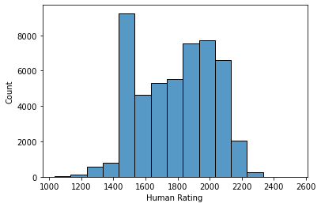

```python
sns.histplot(x = "human_rating", data = train_data, binwidth = 100)
plt.xlabel("Human Rating")
```

Exchanges are very important because players have to know when their hand is bad. Let's see how the number of exchanges per game by human players varies between different ratings.

```python
# Let's first filter the data to extract the human players
only_humans = filtered_turns_data["nickname"].apply(lambda x: str(x) not in ["BetterBot", "HastyBot", "STEEBot"])
only_human_data = filtered_turns_data[only_humans]
```

```python
def is_exchange(row):
  if row.move == "--" and row.turn_type == "Exchange":
    return 1
  else:
    return 0
only_human_data["exchange"] = only_human_data.apply(lambda row: is_exchange(row), axis = 1)
```

```
(-1.0, 12.0)
```

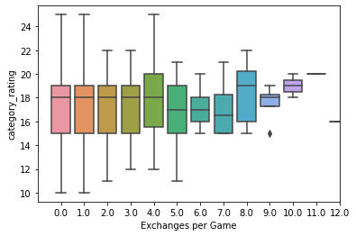

```python
# Train data is also filtered to create train data with only humans
human_train = train_data["nickname"].apply(lambda x: str(x) not in ["BetterBot", "HastyBot", "STEEBot"])
human_train_data = train_data[human_train]
human_train_data = human_train_data.reset_index(drop = True)
# Rating categories are created which group ratings by every 100 points
human_train_data["category_rating"] = human_train_data["rating"].apply(lambda x: x // 100)
human_train_data["exchanges_per_game"] = only_human_data.groupby("game_id")["exchange"].sum()
sns.boxplot(x = "exchanges_per_game", y = "category_rating", data = human_train_data)
plt.xlabel("Exchanges per Game")
plt.xlim(-1, 12)
```

Let's now explore the final score differences between different ratings.

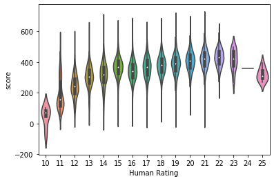

```python
sns.violinplot(x = "category_rating", y = "score", data = human_train_data)
plt.xlabel("Human Rating")
```

With score, we see a more defined trend. Players with a rating between 1200-1300 only seem to score about 250 points per game. However, as the rating increases, so does the average points per game. Players between a rating of 1900-2000 seem to score about 400 points on average while players with a rating beteen 2200-2300 score about 450 points on average. It seems that around 400, the score gets asymtotically harder to increase. One thing to note is the outlier which has a rating of 2500 and a mean score of only 300. This is probably due to very few games at that high rating range. A player probably had a bad day and played one game with a low score. Other than that, the violin plots seem to display a correlation between score and rating. This trend is expected, so now let's explore why. What do players with a higher rating do to score significantly higher points?

Players have the option to build words off of already placed words on the board. Let's explore whether rating correlates to the number of letters that higher ranked players have built off.

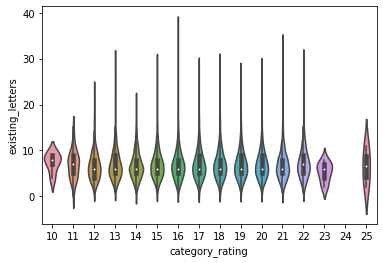

```python
only_human_data["existing_letters"] = only_human_data["move"].apply(lambda move: str(move).count("."))
human_train_data["existing_letters"] = only_human_data.groupby("game_id")["existing_letters"].sum()
sns.violinplot(x = "category_rating", y = "existing_letters", data = human_train_data)
```

Again, there seems to be no visible correlation between the rating of a player and the number of existing letters they use per game. For all ratings, there seems to be a about 7 existing letters used per game. So low rated players are just as good at using existing letters on the board as high rated players.

So far, the only feature which has had a trend with rating is score. In order to maximize score, speed and vocabulary are essential. A player must play fast enough to not run out of time while also not wasting turns by making mistakes.

In order to see if higher rated players make less mistakes, let's see if lower rated players tend to have more words challenged.

```python
def find_challenge(row):
  if row.turn_type == "Exchange" and row.points < 0:
    return row.points * -1
  else:
    return 0
only_human_data["challenges"] = only_human_data.apply(lambda row: find_challenge(row), axis = 1)
```

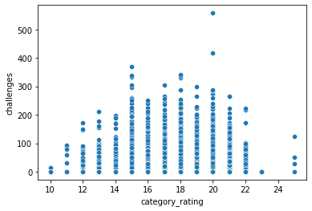

```python
human_train_data["challenges"] = only_human_data.groupby("game_id")["challenges"].sum()
sns.scatterplot(x = "category_rating", y = "challenges", data = human_train_data)
```

Our predictions seem to be incorrect. The distribution of points lost to challenges seems to follow a normal distribution. The low rated players probably do not know enough large scoring words, so when they get challenged they lose a few points. The cluster in the middle indicates the average rated player and from 1500-2100, the players seem to lose the same amount amount of points from challenges (about 150). Higher rated players seem to lose fewer points which would make sense since they are more knowledge of which words actually exist. Players rated 2200-2300 only seem to lose around 75 points from challenges. Overall, there doesn't seem to be a correlation between rating and the number of points lost in challenges.

### Hypothesis Testing and Modeling

Let's test the relationship between the number of points lost due to challenges and rating.

```python
from sklearn import linear_model
valid_challenges = human_train_data[pd.notnull(human_train_data["challenges"])]
y_array = [[element] for element in list(valid_challenges["challenges"])]
x_array = [[element] for element in list(valid_challenges["rating"])]
lin_model = linear_model.LinearRegression()
fit_model = lin_model.fit(x_array, y_array)
r_squared = fit_model.score(x_array, y_array)
print("Points lost to Challenges = "
      + str(fit_model.coef_[0][0]) + " * rating - " + str(fit_model.intercept_[0] * -1))

print("The R^2 Value is " + str(r_squared))
```

```
Points lost to Challenges = 0.000624634435201072 * rating - -5.702040640705303
The R^2 Value is 3.2587399807937345e-05
```

As proven above by the low R value, the relationship between challenges and R value is almost nonexistent. The R value should be close to 1; however, it is of magnitude 10^-5 which is very far from 1.

```python
from sklearn import ensemble, model_selection
valid_exchanges = human_train_data[pd.notnull(human_train_data["exchanges_per_game"])]
randomForest = ensemble.RandomForestClassifier(n_estimators=40, max_depth = 20)
random_forest_scores = model_selection.cross_val_score(randomForest,
                                        valid_exchanges[["score", "exchanges_per_game"]],
                                        valid_exchanges["rating"],
                                        cv = 10,
                                        scoring = "neg_root_mean_squared_error")
print("The root mean squared error is " + str(random_forest_scores.mean()))
```

```
The root mean squared error is -361.1966623522415
```

### Conclusion

- Analyzing the length of each move and how that could correlate to rating
- Looking at positional trends and analyzing if higher rated players play their move more strategically on the board than lower rated players. Since the board contains squares which grant extra points this could result in a trend.